# Machine Learning Record

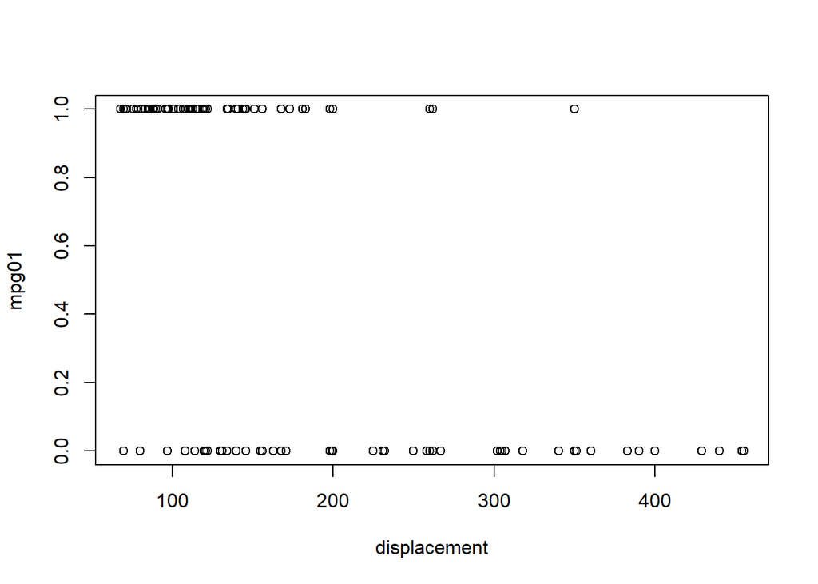

```r
plot(mpg01~displacement,data=Auto_new)
```

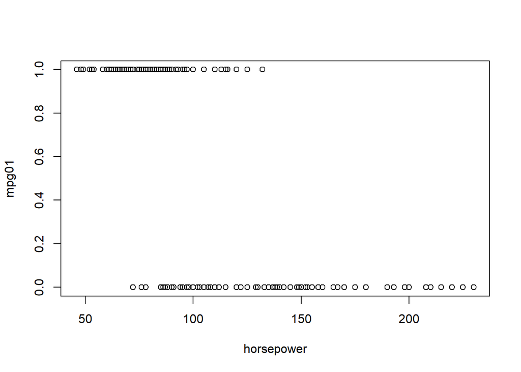

```r
plot(mpg01~horsepower,data=Auto_new)
```

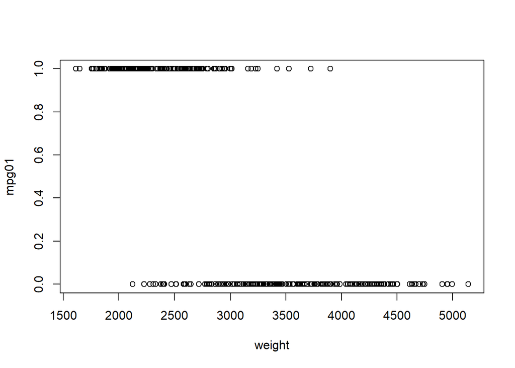

```r
plot(mpg01~weight,data=Auto_new)
```

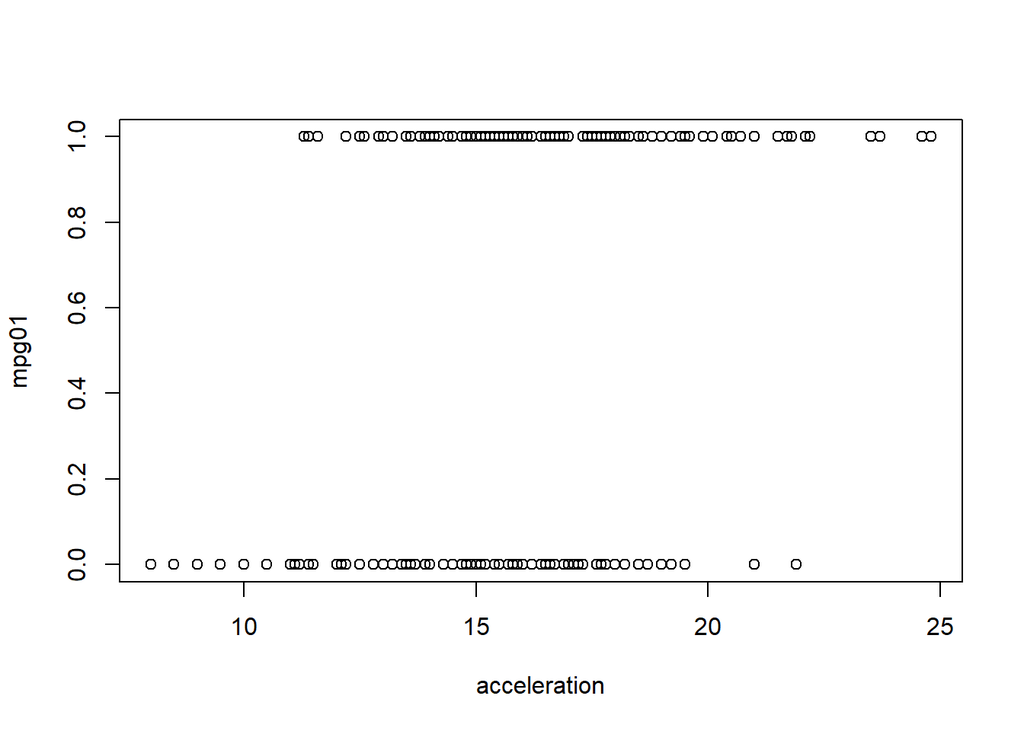

```r
plot(mpg01~acceleration,data=Auto_new)
```

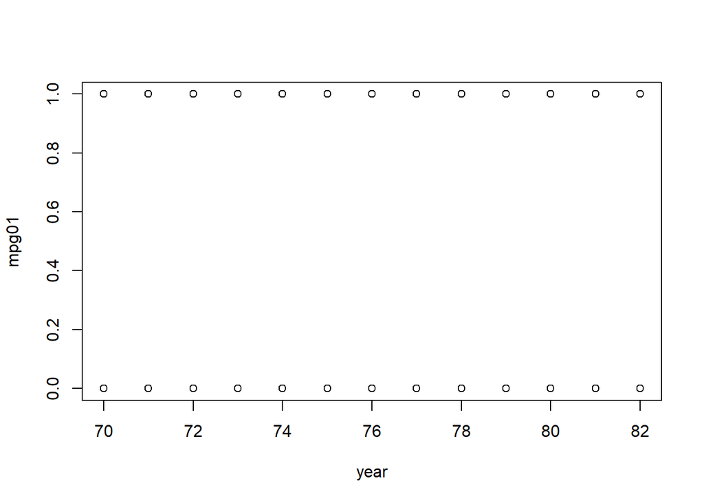

```r
plot(mpg01~year,data=Auto_new)
```

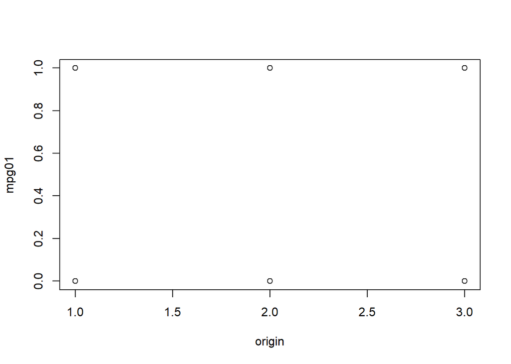

```r
plot(mpg01~origin,data=Auto_new)
```

**Interpretation** displacement, horsepower, weight and acceleration can be used as Predictors to predict mpg01

**(c) Split the data into a training set and a test set.**

```r
Tr=sample(nrow(Auto_new),.70*nrow(Auto_new))
head(Tr)
```

```
## [1] 389 302  95 195 322 264
```

```r
Train_A1=Auto_new[Tr,]
Test_A1=Auto_new[-Tr,]
```

**(d) Perform LDA on the training data in order to predict mpg01 using the variables that seemed most associated with mpg01 in (b). What is the test error of the model obtained?**

```r
library(MASS)
LDA_A1= lda(Train_A1$mpg01~displacement+horsepower+weight+acceleration,Train_A1)
```

```r
pred_A1=predict(LDA_A1,Test_A1)
```

```r
table(pred_A1$class, Test_A1$mpg01)
```

```
##
##      0  1
##   0 49  3
##   1  8 58
```

```r
(57+50)/(57+3+8+50)
```

```
## [1] 0.9067797
```

```r
QDA_A1= lda(Train_A1$mpg01~displacement+horsepower+weight+acceleration,Train_A1)
```

```r
pred2_A1=predict(QDA_A1,Test_A1)
```

```r
table(pred2_A1$class, Test_A1$mpg01)
```

```
##
##      0  1
##   0 49  3
##   1  8 58
```

```r
mean(unlist(pred2_A1) == Test_A1$mpg01)
```

```
## [1] 0.006355932
```

**(f) Perform logistic regression on the training data in order to predict mpg01 using the variables that seemed most associated with mpg01 in (b). What is the test error of the model obtained?**

```r
lr_A1 = glm(Train_A1$mpg01~displacement+horsepower+weight+acceleration,Train_A1,family='binomial')
```

```r
summary(lr_A1)
```

[output not shown]

```r
prob_lrA1=predict(lr_A1,Test_A1,type='response')
head(prob_lrA1)
```

```
##            7           12           17           19           27           29
## 1.851356e-05 1.276766e-03 3.944626e-01 9.144390e-01 4.325878e-04 3.968188e-04
```

```r
pred_lrA1=rep('0', nrow(Test_A1))
pred_lrA1[prob_lrA1>0.5] = "1"
```

```r
table(pred_lrA1,Test_A1$mpg01)
```

```
##
## pred_lrA1  0  1
##         0 52  5
##         1  5 56
```

```r
mean(pred_lrA1==Test_A1$mpg01)
```

```
## [1] 0.9152542
```

**(g) Perform KNN on the training data, with several values of K, in order to predict mpg01. Use only the variables that seemed most associated with mpg01 in (b). What test errors do you obtain? Which value of K seems to perform the best on this data set?**

```r
tr_x=data.frame(Train_A1[,c('displacement','horsepower','weight','acceleration')])
te_x=data.frame(Test_A1[,c('displacement','horsepower','weight','acceleration')])
tr_y=Train_A1[,"mpg01"]
te_y=Test_A1[,"mpg01"]
```

```r
library(class)
knn_A1=knn(tr_x,te_x,tr_y,k=2)
```

```r
table(knn_A1,te_y)
```

```
##       te_y
## knn_A1  0  1
##      0 52  7
##      1  5 54
```

```r
mean(knn_A1==te_y)
```

```
## [1] 0.8983051
```

**7.In Sections 5.3.2 and 5.3.3, we saw that the cv.glm() function can be used in order to compute the LOOCV test error estimate. Alternatively, one could compute those quantities using just the glm() and predict.glm() functions, and a for loop. You will now take this approach in order to compute the LOOCV error for a simple logistic regression model on the Weekly data set. Recall that in the context of classification problems, the LOOCV error is given in (5.4).**

**(a) Fit a logistic regression model that predicts Direction using Lag1 and Lag2.**

```r
library(ISLR)
fit_lrw = glm(Weekly$Direction~Lag1+Lag2, Weekly, family = 'binomial')
```

**(b) Fit a logistic regression model that predicts Direction using Lag1 and Lag2 using all but the first observation.**

```r
fit_lrw1 = glm(Weekly[-1,]$Direction~Lag1+Lag2, Weekly[-1,], family= 'binomial')
```

**(c) Use the model from (b) to predict the direction of the first observation. You can do this by predicting that the first observation will go up if P (Direction=“Up”|Lag1, Lag2) > 0.5. Was this observation correctly classified?**

```r
predict(fit_lrw1,Weekly[1,],type = 'response')
```

```
##         1
## 0.5713923
```

```r
Weekly[1,]$Direction
```

```
## [1] Down
## Levels: Down Up
```

**(d) Write a for loop from i = 1 to i = n, where n is the number of observations in the data set, that performs each of the following steps:** **i. Fit a logistic regression model using all but the ith observation to predict Direction using Lag1 and Lag2.** **ii. Compute the posterior probability of the market moving up for the ith observation.** **iii. Use the posterior probability for the ith observation in order to predict whether or not the market moves up.** **iv. Determine whether or not an error was made in predicting the direction for the ith observation. If an error was made, then indicate this as a 1, and otherwise indicate it as a 0.**

```r
attach(Weekly)
error<- rep(0, nrow(Weekly))
for (i in 1:nrow(Weekly))
{fit_weekly=glm(Direction~Lag1+Lag2, data = Weekly[-i,], family = 'binomial')
  pred_weekly = predict(fit_weekly,Weekly[i,], type = 'response')
if(pred_weekly>0.5)
     pred1 = "Up"
else
     pred1="Down"
if(pred1 != Weekly[i,]$Direction)
error[i]=1
}
```

**(e) Take the average of the n numbers obtained in (d)iv in order to obtain the LOOCV estimate for the test error. Comment on the results.**

```r
mean(error)
```

```
## [1] 0.4499541
```

```r
prop.table(table(Weekly$Direction))
```

```
##
##      Down        Up
## 0.4444444 0.5555556
```

**Interpretaion** We can see that a classifier that predicted that the Direction of the S&P 500 will go Up every week between 1990 and 2010 would have achieved an error of 0.444, so if the LOOCV estimate is anything to go by, our classifier isn’t much good.

**8.In this exercise, we will predict the number of applications received using the other variables in the College data set.**

**(a) Split the data set into a training set and a test set.**

```r
library(ISLR)
attach(College)
set.seed(11)
 subset<-sample(nrow(College),nrow(College)*0.7)
train<-College[subset,]
test<-College[-subset,]
```

**(b) Fit a linear model using least squares on the training set, and report the test error obtained.**

```r
ls.full<-lm(Apps~.,data=train)
summary(ls.full)
```

```
##
## Call:
## lm(formula = Apps ~ ., data = train)
##
## Residuals:
##     Min      1Q  Median      3Q     Max
## -5090.2  -445.7   -32.9   371.5  6934.7
##
## Coefficients:
##               Estimate Std. Error t value Pr(>|t|)
## (Intercept) -3.118e+02  5.315e+02  -0.587 0.557673
## PrivateYes  -5.306e+02  1.838e+02  -2.887 0.004055 **
## Accept       1.677e+00  5.130e-02  32.696  < 2e-16 ***
## Enroll      -1.345e+00  2.503e-01  -5.373 1.17e-07 ***
## Top10perc    6.342e+01  7.056e+00   8.989  < 2e-16 ***
## Top25perc   -2.215e+01  5.752e+00  -3.851 0.000132 ***
## F.Undergrad  1.065e-01  4.804e-02   2.217 0.027061 *
## P.Undergrad  7.098e-03  5.427e-02   0.131 0.896005
## Outstate    -9.784e-02  2.492e-02  -3.927 9.77e-05 ***
## Room.Board   1.357e-01  6.385e-02   2.125 0.034068 *
## Books       -2.035e-01  3.352e-01  -0.607 0.544074
## Personal     1.461e-01  9.088e-02   1.608 0.108475
## PhD         -9.598e+00  5.962e+00  -1.610 0.108033
## Terminal    -7.469e-01  6.563e+00  -0.114 0.909426
## S.F.Ratio    1.392e+01  1.697e+01   0.820 0.412433
## perc.alumni -1.081e+00  5.514e+00  -0.196 0.844605
## Expend       7.559e-02  1.499e-02   5.041 6.39e-07 ***
## Grad.Rate    1.039e+01  3.884e+00   2.675 0.007716 **
## ---
## Signif. codes:  0 '***' 0.001 '**' 0.01 '*' 0.05 '.' 0.1 ' ' 1
##
## Residual standard error: 1143 on 525 degrees of freedom
## Multiple R-squared:  0.9249, Adjusted R-squared:  0.9225
## F-statistic: 380.4 on 17 and 525 DF,  p-value: < 2.2e-16
```

```r
predicted.apps<-predict(ls.full,test)
testerror<-mean((test$Apps-predicted.apps)^2)
head(testerror)
```

```
## [1] 680349.5
```

**(c) Fit a ridge regression model on the training set, with λ chosen by cross-validation. Report the test error obtained.**

```r
train.mat<-model.matrix(Apps~.,data=train)
test.mat<-model.matrix(Apps~.,data=test)
grid<-10^seq(4,-2,length=100)
 library(glmnet)
ridge<-glmnet(train.mat,train$Apps,alpha=0,lambda=grid,thresh = 1e-12)
 cv.ridge<-cv.glmnet(train.mat,train$Apps,alpha=0,lambda=grid,thresh=1e-12)
 bestlam.ridge<-cv.ridge$lambda.min
 bestlam.ridge
```

```
## [1] 0.01
```

```r
pred.newridge<-predict(ridge,s=bestlam.ridge,newx =test.mat)
mean((test$Apps-pred.newridge)^2)
```

```
## [1] 680304
```

```
This is slightly less than the one for Least Square Model
```

**(d) Fit a lasso model on the training set, with λ chosen by crossvalidation. Report the test error obtained, along with the number of non-zero coefficient estimates.**

```r
lasso<-glmnet(train.mat,train$Apps,alpha=1,lambda=grid,thresh = 1e-12)
 cv.lasso<-cv.glmnet(train.mat,train$Apps,alpha=1,lambda=grid,thresh=1e-12)
 bestlam.lasso<-cv.lasso$lambda.min
 bestlam.lasso
```

```
## [1] 0.01
```

```r
pred.newlasso<-predict(lasso,s=bestlam.lasso,newx =test.mat)
mean((test$Apps-pred.newlasso)^2)
```

```
## [1] 680231.6
```

```r
predict(lasso,s=bestlam.lasso,type="coefficients")
```

```
## 19 x 1 sparse Matrix of class "dgCMatrix"
##                        s1
## (Intercept) -3.119599e+02
## (Intercept)  .
## PrivateYes  -5.306365e+02
## Accept       1.677124e+00
## Enroll      -1.344497e+00
## Top10perc    6.341209e+01
## Top25perc   -2.214441e+01
## F.Undergrad  1.064107e-01
## P.Undergrad  7.114242e-03
## Outstate    -9.782167e-02
## Room.Board   1.356616e-01
## Books       -2.033689e-01
## Personal     1.461040e-01
## PhD         -9.597043e+00
## Terminal    -7.472047e-01
## S.F.Ratio    1.391879e+01
## perc.alumni -1.081542e+00
## Expend       7.558538e-02
## Grad.Rate    1.038614e+01
```

[output not shown]

**(e) Fit a PCR model on the training set, with M chosen by crossvalidation. Report the test error obtained, along with the value of M selected by cross-validation.**

```r
library(pls)
```

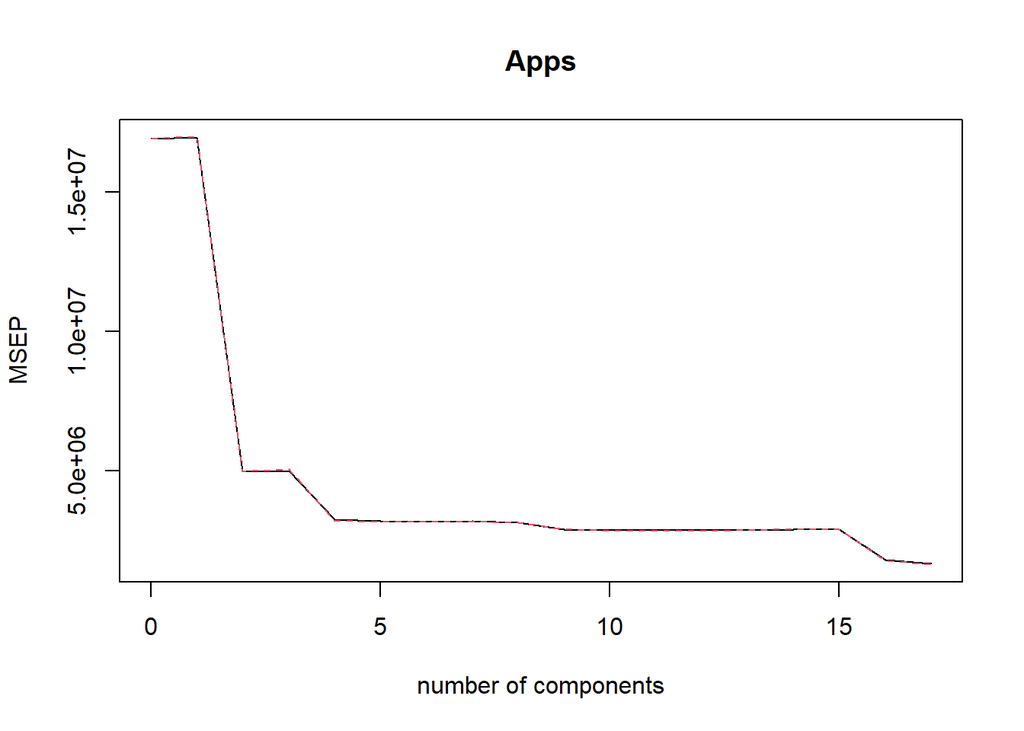

```r
pcrmodel<-pcr(Apps~.,data=train,scale=TRUE,validation="CV")
validationplot(pcrmodel,val.type="MSEP")
```

```r
predict.pcr<-predict(pcrmodel,test,ncomp=17)
 mean((test$Apps-predict.pcr)^2)
```

```
## [1] 680349.5
```

[output not shown]

**(f) Fit a PLS model on the training set, with M chosen by crossvalidation. Report the test error obtained, along with the value of M selected by cross-validation.**

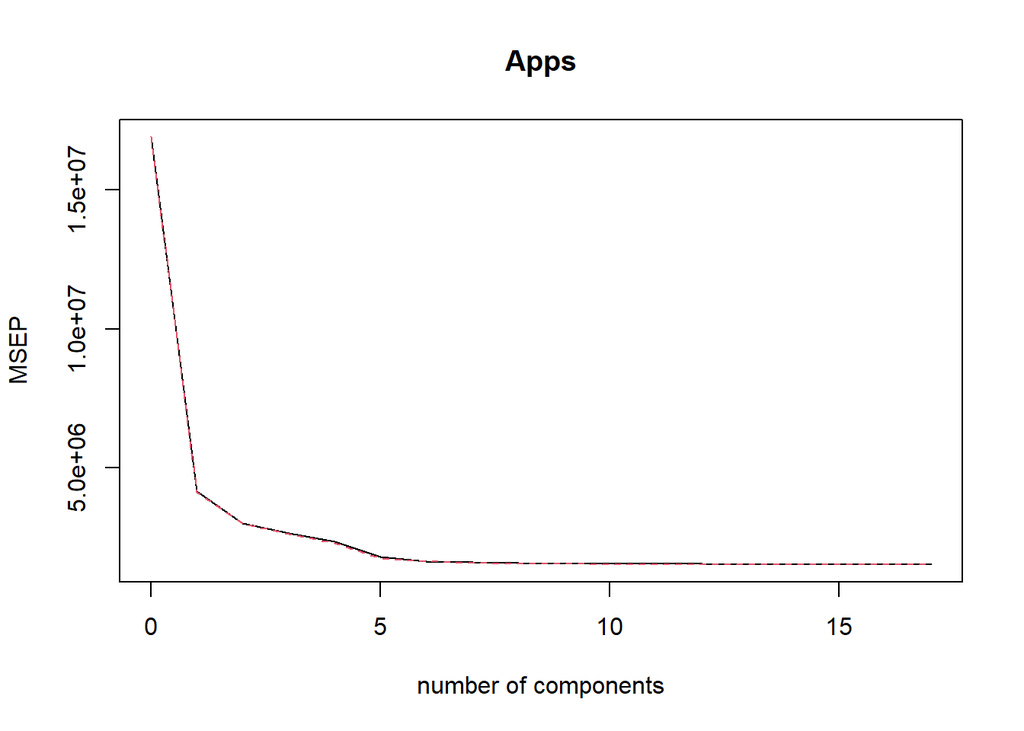

```r
plsrmodel<-plsr(Apps~.,data=train,scale=TRUE,validation="CV")
 validationplot(plsrmodel,val.type="MSEP")
```

```r
predict.plsr<-predict(plsrmodel,test,ncomp=10)
mean((test$Apps-predict.plsr)^2)
```

```
## [1] 661659.2
```

[output not shown]

**(g) Comment on the results obtained. How accurately can we predict the number of college applications received? Is there much difference among the test errors resulting from these five approaches?**

[output not shown]